# Statistica_Descrittiva_Project

Lorenzo Canobbio

2025-02-19

# VARIABLES ANALYSIS

```r
library(readr)
realestate_texas <- read_csv("C:/Users/Utente/Downloads/realestate_texas.csv")
View(realestate_texas)
```

The imported dataset contains 240 observations across 8 columns. Below is an identification and description of the statistical variables in the dataset:

-city (Type: Qualitative Nominal): Represents the city associated with the observation. A categorical variable with no intrinsic order. Possible analysis: distribution of observations by city, comparisons between cities for quantitative variables (e.g., sales).

-year (Type: Quantitative Continuous to be treated as Ordinal Qualitative in this case): Represents the year of the observation. Implies a temporal dimension. Possible analysis: assessing yearly trends in other variables.

-month (Type: Qualitative Nominal (cyclic) but coded in numbers): Represents the month of the observation, with 12 distinct values (1 to 12). Implies a seasonal component. Possible analysis: identifying seasonal patterns in sales, volume, or median price.

-sales (Type: Quantitative Discrete): Indicates the number of real estate sales. Possible analysis: distribution analysis, identifying trends over time, or city-based comparisons.

-volume (Type: Quantitative Continuous): Represents sales volume in millions. Possible analysis: evaluation of total market activity, mean or temporal variation analysis.

-median_price (Type: Quantitative Continuous): Indicates the median price of real estate sales. Possible analysis: distribution analysis, spatial and temporal variations, identifying correlations with other variables.

-listings (Type: Quantitative Discrete): Represents the number of active sales listings. Possible analysis: temporal trends, relationship with sales or available inventory.

-months_inventory (Type: Quantitative Continuous): Represents the number of months required to sell the current inventory at the current sales rate. Possible analysis: assessment of market balance (supply vs. demand).

The variables year and month imply a time dimension: Combining year and month: These two variables can be combined into a single temporal variable (e.g., timestamp or year-month) for more sophisticated time-based analyses, such as time series modeling. Seasonal Patterns and Trends: Separate analyses of seasonal patterns (monthly) and long-term trends (yearly) can be conducted using tools like time series decomposition.

Categorical Variables (e.g., city): Distribution of observations across categories. Comparisons with summary statistics (mean, median).

Temporal Variables: Trends, seasonality, and time series analysis.

Quantitative Variables (sales, volume, median_price, listings, months_inventory): Correlations. Trend analysis (e.g., linear regressions over time). Spatial comparisons (between cities).

```r
attach(realestate_texas) #in order to use dataset variables, without $
```

# POSITION INDEXES, VARIABILITY INDEXES AND SHAPE INDEXES

```r
#POSITION INDEXES
#Modal values
library(knitr)
```

```r
quant_variables <- c("sales", "volume", "median_price", "listings", "months_inventory")

get_mode <- function(x) {
  uniqx <- unique(x)
  uniqx[which.max(tabulate(match(x, uniqx)))]
}

modal_values <- lapply(quant_variables, function(var) get_mode(get(var)))

format_number <- function(x) {
  ifelse(x %% 1 == 0, as.character(x), sprintf("%.2f", round(x, 2)))
}

formatted_modal_values <- sapply(modal_values, format_number)

mode_table <- data.frame(
  Variable = c("Sales", "Volume", "Median Price", "Listings", "Months Inventory"),
  Modal_value = formatted_modal_values
)

kable(mode_table, caption = "Quantitative variables modal values")
```

Quantitative variables modal values

| Variable | Modal_value |
| --- | --- |
| Sales | 124 |
| Volume | 35.34 |
| Median Price | 130000 |
| Listings | 1581 |
| Months Inventory | 8.10 |

Position indexes are synthetic indices, functions of the resulting data in single values that describe in summary the distribution of our data. Modal value can be defined for every type of variable: it’s the modality with the highest absolute frequency.

```r
#Maximum and minimum
get_min_max <- function(x) {
  return(c(min(x), max(x)))
}

min_max_values <- sapply(quant_variables, function(var) get_min_max(get(var)))

formatted_min_max_values <- apply(min_max_values, 2, function(x) sapply(x, format_number))

min_max_table <- data.frame(
  Min = formatted_min_max_values[1, ],
  Max = formatted_min_max_values[2, ]
)

kable(min_max_table, caption = "Maximum and Minimum Values for Each Variable")
```

Maximum and Minimum Values for Each Variable

|  | Min | Max |
| --- | --- | --- |
| sales | 79 | 423 |
| volume | 8.17 | 83.55 |
| median_price | 73800 | 180000 |
| listings | 743 | 3296 |
| months_inventory | 3.40 | 14.90 |

They represent the maximum value and the minimum value of a specific variable.

```r
#Median values
get_median <- function(x) {
  return(median(x))
}

median_values <- sapply(quant_variables, function(var) get_median(get(var)))

formatted_median_values <- sapply(median_values, format_number)

median_table <- data.frame(
  Median = formatted_median_values
)

kable(median_table, caption = "Median Values for Each Variable")
```

Median Values for Each Variable

|  | Median |
| --- | --- |
| sales | 175.50 |
| volume | 27.06 |
| median_price | 134500 |
| listings | 1618.50 |
| months_inventory | 8.95 |

It is a robust index, which does not account for any outliers within the distribution, and it is calculated for both quantitative and ordinal qualitative variables and represents the 50th percentile. It is defined by sorting the data in ascending or descending order and taking the value that is exactly in the middle of the series.

```r
#Quantiles and quartiles
get_quantiles_and_summary <- function(var) {
  quantiles_10 <- quantile(var, seq(0, 1, 0.1))
  quantiles_100 <- quantile(var, seq(0, 1, 0.01))
  summary_stats <- summary(var)
  return(list(quantiles_10 = quantiles_10, quantiles_100 = quantiles_100, summary = summary_stats))
}

results <- lapply(quant_variables, function(var) get_quantiles_and_summary(get(var)))

names(results) <- quant_variables
results
```

```
## $sales
## $sales$quantiles_10
##    0%   10%   20%   30%   40%   50%   60%   70%   80%   90%  100%
##  79.0 101.9 120.6 135.0 155.0 175.5 197.0 228.5 271.0 302.1 423.0
##
## $sales$quantiles_100
##     0%     1%     2%     3%     4%     5%     6%     7%     8%     9%    10%
##  79.00  80.39  87.68  89.17  91.56  93.00  94.34  96.73  98.24 101.00 101.90
##    11%    12%    13%    14%    15%    16%    17%    18%    19%    20%    21%
## 104.29 107.68 108.07 110.00 111.00 113.00 114.00 115.02 117.82 120.60 123.00
##    22%    23%    24%    25%    26%    27%    28%    29%    30%    31%    32%
## 124.00 124.00 125.00 127.00 128.14 130.00 130.92 132.62 135.00 137.27 140.48
##    33%    34%    35%    36%    37%    38%    39%    40%    41%    42%    43%
## 143.00 144.52 147.65 149.00 149.43 150.00 151.21 155.00 159.00 160.00 161.54
##    44%    45%    46%    47%    48%    49%    50%    51%    52%    53%    54%
## 163.00 164.00 165.94 167.66 169.72 173.11 175.50 176.89 180.28 181.67 182.00
##    55%    56%    57%    58%    59%    60%    61%    62%    63%    64%    65%
## 186.00 186.84 189.00 191.86 196.00 197.00 198.00 200.36 202.00 205.92 208.35
##    66%    67%    68%    69%    70%    71%    72%    73%    74%    75%    76%
## 211.48 213.65 219.04 224.91 228.50 233.69 238.00 239.94 244.00 247.00 253.00
##    77%    78%    79%    80%    81%    82%    83%    84%    85%    86%    87%
## 254.03 258.84 262.00 271.00 272.59 277.94 282.00 283.52 287.30 289.00 292.93
##    88%    89%    90%    91%    92%    93%    94%    95%    96%    97%    98%
## 295.32 298.00 302.10 314.47 321.40 326.54 333.98 347.30 357.00 367.64 372.32
##    99%   100%
## 396.54 423.00
##
## $sales$summary
##    Min. 1st Qu.  Median    Mean 3rd Qu.    Max.
##    79.0   127.0   175.5   192.3   247.0   423.0
##
##
## $volume
## $volume$quantiles_10
##      0%     10%     20%     30%     40%     50%     60%     70%     80%     90%
##  8.1660 13.0967 16.1206 19.0344 23.9976 27.0625 31.8436 36.9307 45.5920 53.7391
##    100%
## 83.5470
##
## $volume$quantiles_100
```

[output cut: 113 more lines]

```
##  8.600  8.700  8.700  8.733  8.800  8.900  8.950  9.000  9.000  9.067  9.100
##    55%    56%    57%    58%    59%    60%    61%    62%    63%    64%    65%
##  9.100  9.200  9.300  9.362  9.400  9.400  9.500  9.618  9.814  9.996 10.000
##    66%    67%    68%    69%    70%    71%    72%    73%    74%    75%    76%
## 10.174 10.213 10.400 10.491 10.530 10.600 10.700 10.747 10.800 10.950 11.100
##    77%    78%    79%    80%    81%    82%    83%    84%    85%    86%    87%
## 11.200 11.300 11.300 11.400 11.400 11.500 11.600 11.600 11.615 11.700 11.700
##    88%    89%    90%    91%    92%    93%    94%    95%    96%    97%    98%
## 11.932 12.000 12.210 12.300 12.400 12.600 12.898 13.015 13.344 13.483 13.844
##    99%   100%
## 14.500 14.900
##
## $months_inventory$summary
##    Min. 1st Qu.  Median    Mean 3rd Qu.    Max.
##   3.400   7.800   8.950   9.193  10.950  14.900
```

Quantiles are those values that split a set of data arranged in sequential order into several parts. Quartiles are those three values of the ordered data series that divide the series itself into quarters, that is, into four equal parts. They represent the 25th, 50th and 75th percentiles, respectively. A percentile, for example, Xp is that value that divides the distribution of values into two parts, such that p% of the values is less than Xp and (1-p)% is greater than Xp.

```r
#Mean values
get_mean <- function(x) {
  return(mean(x))
}

mean_values <- sapply(quant_variables, function(var) get_mean(get(var)))

formatted_mean_values <- sapply(mean_values, format_number)

mean_table <- data.frame(
  Mean = formatted_mean_values
)

kable(mean_table, caption = "Mean Values for Each Variable")
```

Mean Values for Each Variable

|  | Mean |
| --- | --- |
| sales | 192.29 |
| volume | 31.01 |
| median_price | 132665.42 |
| listings | 1738.02 |
| months_inventory | 9.19 |

It is that value which is obtained by summing all the values of a quantitative variable, and then dividing by the number of values.

```r
#VARIABILITY INDEXES
#Values range
get_range <- function(x) {
  return(range(x))
}

range_values <- sapply(quant_variables, function(var) get_range(get(var)))

formatted_range_values <- apply(range_values, 2, function(x) sapply(x, format_number))

range_table <- data.frame(
  Min = formatted_range_values[1, ],
  Max = formatted_range_values[2, ]
)

kable(range_table, caption = "Range (Min and Max) for Each Variable")
```

Range (Min and Max) for Each Variable

|  | Min | Max |
| --- | --- | --- |
| sales | 79 | 423 |
| volume | 8.17 | 83.55 |
| median_price | 73800 | 180000 |
| listings | 743 | 3296 |
| months_inventory | 3.40 | 14.90 |

Position indices alone are not enough, since they do not give us information about variability, how and how much the data are distributed over their domain or range. The variability of a distribution measures the tendency of units to assume different modes or values of the variable. Variability indices summarize the diversity among units in terms between two values of the distribution or observed modes.They make it possible, thus, to compare different distributions with each other. Variable range represents the difference between maximum value and minimum value of that specific variable (it refers for only observed values).

```r
#InterQuartile range (IQR)
get_iqr <- function(x) {
  return(IQR(x))
}

iqr_values <- sapply(quant_variables, function(var) get_iqr(get(var)))

formatted_iqr_values <- sapply(iqr_values, format_number)

iqr_table <- data.frame(
  IQR = formatted_iqr_values
)

kable(iqr_table, caption = "Interquartile Range (IQR) for Each Variable")
```

Interquartile Range (IQR) for Each Variable

|  | IQR |
| --- | --- |
| sales | 120 |
| volume | 23.23 |
| median_price | 32750 |
| listings | 1029.50 |
| months_inventory | 3.15 |

It is the difference between the 3rd quartile and the 1st quartile and it shows the range of variation in the central body of data, i.e., 50% of the data between the two quartiles. Robust index if there are outliers in the data distribution.

```r
#Variance and standard deviation
options(scipen = 999)

get_variance_sd <- function(x) {
  return(c(variance = var(x), sd = sd(x)))
}

variance_sd_values <- sapply(quant_variables, function(var) get_variance_sd(get(var)))

formatted_variance_values <- sapply(variance_sd_values["variance", ], format_number)
formatted_sd_values <- sapply(variance_sd_values["sd", ], format_number)

variance_sd_table <- data.frame(
  Variance = formatted_variance_values,
  Standard_Deviation = formatted_sd_values
)

kable(variance_sd_table, caption = "Variance and Standard Deviation for Each Variable")
```

Variance and Standard Deviation for Each Variable

|  | Variance | Standard_Deviation |
| --- | --- | --- |
| sales | 6344.30 | 79.65 |
| volume | 277.27 | 16.65 |
| median_price | 513572983.09 | 22662.15 |
| listings | 566568.97 | 752.71 |
| months_inventory | 5.31 | 2.30 |

Variance shows the degree of dispersion around the mean value. Standard deviation represents the square root of the variance and gives us an index of variability in the same unit as the observed data (a measure more consistent with the source data). The latter is an absolute index and, therefore, is affected by both the unit of measurement of the variable and the order of magnitude of the data. If the mean values are very different, the standard deviation may not be a suitable measure for comparing different data.

```r
#Coefficient of variation
CV <- function(x) {
  return(sd(x) / mean(x) * 100)
}

cv_values <- sapply(quant_variables, function(var) CV(get(var)))

formatted_cv_values <- sapply(cv_values, format_number)

cv_table <- data.frame(
  CV = formatted_cv_values
)

kable(cv_table, caption = "Coefficient of Variation (CV) for Each Variable")
```

Coefficient of Variation (CV) for Each Variable

|  | CV |
| --- | --- |
| sales | 41.42 |
| volume | 53.71 |
| median_price | 17.08 |
| listings | 43.31 |
| months_inventory | 25.06 |

The coefficient of variation makes it possible to compare the variability of a sample relative to two different variables, or the variability of two samples relative to the same variable. This coefficient, however, is problematic if the variable has both positive and negative values, or in the case of a conventional zero in the measurement scale.

```r
#SHAPE INDEXES
#Skewness index
library(moments)
```

```r
skew_values <- sapply(quant_variables, function(var) skewness(get(var)))

formatted_skew_values <- sapply(skew_values, format_number)

skewness_table <- data.frame(
  Skewness = formatted_skew_values
)

kable(skewness_table, caption = "Skewness for Each Variable")
```

Skewness for Each Variable

|  | Skewness |
| --- | --- |
| sales | 0.72 |
| volume | 0.88 |
| median_price | -0.36 |
| listings | 0.65 |
| months_inventory | 0.04 |

These indices refer to skewness and kurtosis, features of the distribution that refer to the central moment of order three and four of a random variable, respectively. A distribution is said to be symmetrical if it is possible to identify a vertical axis that cuts the distribution into two specularly equal parts (the variable must be sortable).

```r
#Kurtosis coefficient
kurt_values <- sapply(quant_variables, function(var) kurtosis(get(var)) - 3)

formatted_kurt_values <- sapply(kurt_values, format_number)

kurtosis_table <- data.frame(
  Excess_Kurtosis = formatted_kurt_values
)

kable(kurtosis_table, caption = "Kurtosis for Each Variable")
```

Kurtosis for Each Variable

|  | Excess_Kurtosis |
| --- | --- |
| sales | -0.31 |
| volume | 0.18 |
| median_price | -0.62 |
| listings | -0.79 |
| months_inventory | -0.17 |

Kurtosis can be defined as a measure of crushing/extension of the shape of a distribution relative to the normal distribution.

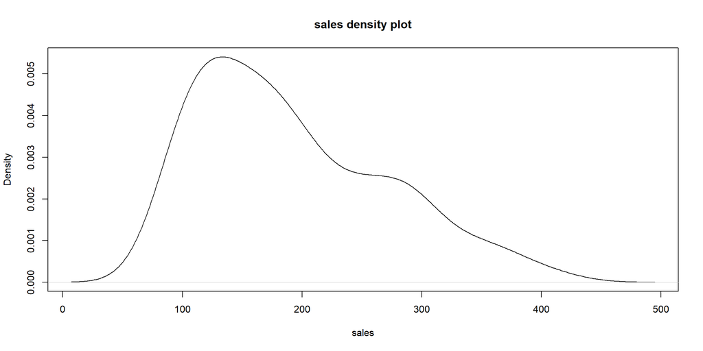

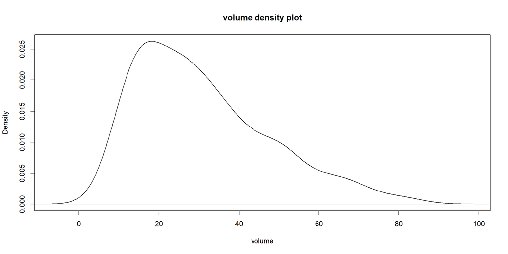

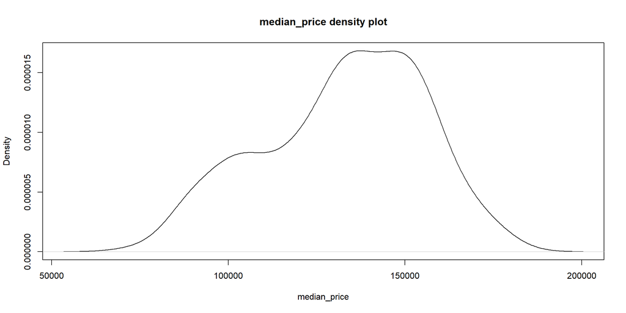

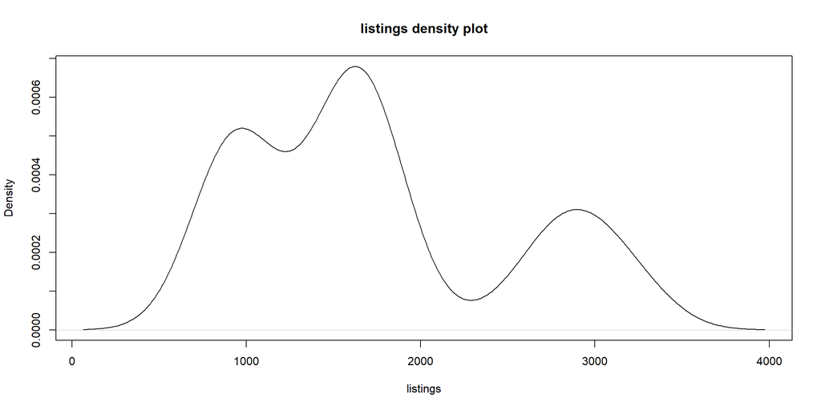

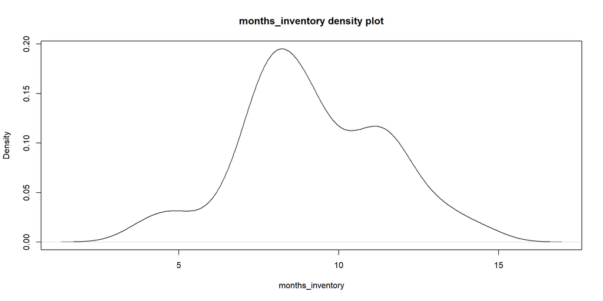

```r
for (var in quant_variables) {
  plot(density(get(var)), main = paste(var, "density plot"), xlab = var)
}
```

This in order to see, in a graphical way, the distribution of these quantitative variables.

```r
#frequency distribution for qualitative variables
freq_distr <- function(x){
  N <- length(x)
  freq <- table(x)
  rel_freq <- freq / N
  cum_freq <- cumsum(freq)
  cum_rel_freq <- cumsum(freq) / N
  return(cbind(freq, rel_freq, cum_freq, cum_rel_freq))
}

city_freq <- freq_distr(city)
year_freq <- freq_distr(year)
month_freq <- freq_distr(month)

formatted_city_freq <- apply(city_freq, 2, function(col) sapply(col, format_number))
formatted_year_freq <- apply(year_freq, 2, function(col) sapply(col, format_number))
formatted_month_freq <- apply(month_freq, 2, function(col) sapply(col, format_number))

city_freq_table <- data.frame(formatted_city_freq)
year_freq_table <- data.frame(formatted_year_freq)
month_freq_table <- data.frame(formatted_month_freq)

kable(city_freq_table, caption = "Frequency Distribution for City")
```

Frequency Distribution for City

|  | freq | rel_freq | cum_freq | cum_rel_freq |
| --- | --- | --- | --- | --- |
| Beaumont | 60 | 0.25 | 60 | 0.25 |
| Bryan-College Station | 60 | 0.25 | 120 | 0.50 |
| Tyler | 60 | 0.25 | 180 | 0.75 |
| Wichita Falls | 60 | 0.25 | 240 | 1 |

```r
kable(year_freq_table, caption = "Frequency Distribution for Year")
```

Frequency Distribution for Year

|  | freq | rel_freq | cum_freq | cum_rel_freq |
| --- | --- | --- | --- | --- |
| 2010 | 48 | 0.20 | 48 | 0.20 |
| 2011 | 48 | 0.20 | 96 | 0.40 |
| 2012 | 48 | 0.20 | 144 | 0.60 |
| 2013 | 48 | 0.20 | 192 | 0.80 |
| 2014 | 48 | 0.20 | 240 | 1 |

```r
kable(month_freq_table, caption = "Frequency Distribution for Month")
```

Frequency Distribution for Month

| freq | rel_freq | cum_freq | cum_rel_freq |
| --- | --- | --- | --- |
| 20 | 0.08 | 20 | 0.08 |
| 20 | 0.08 | 40 | 0.17 |
| 20 | 0.08 | 60 | 0.25 |
| 20 | 0.08 | 80 | 0.33 |
| 20 | 0.08 | 100 | 0.42 |
| 20 | 0.08 | 120 | 0.50 |
| 20 | 0.08 | 140 | 0.58 |
| 20 | 0.08 | 160 | 0.67 |
| 20 | 0.08 | 180 | 0.75 |
| 20 | 0.08 | 200 | 0.83 |
| 20 | 0.08 | 220 | 0.92 |
| 20 | 0.08 | 240 | 1 |

Here, we have frequency tables for the others qualitative variables.